# Data Simulation of Blood Based Markers

Kate Jamboretz, University of San Francisco Professional Master’s of Biotechnology ’17

Background

- Assignment: Data Simulation Project
- Course: Projects in Statistical Computing for Biomedical Data Analytics
- Instructor: Dr. Patricia Francis-Lyon

E Schwarz, PC Guest, J Steiner, B Bogerts, S Bahn. Identification of blood-based molecular signatures for prediction of response and relapse in schizophrenia patients [Translational Psychiatry (2012) 2, e82; doi:10.1038/tp.2012.3](http://www.nature.com/tp/journal/v2/n2/full/tp20123a.html)

This data simulation focuses on a portion of the work Schwarz et al. performed in the above paper, focusing on predictors until time to relapse for Schizophrenia patients and the variables for which we have the most information. The paper itself had a broader scope with four main goals, as quoted from the paper abstract:

"

1. to identifiy molecules associated with symptom severity in antipsychotic naive and unmedicated patients
2. to determine biomarker signatures that could predict response over a 6-week treatment period
3. to identify molecular panels that could predict the time to relapse in a cross-sectional population of patients in remission and
4. to investigate how the biological relapse signature changed throughout the treatment course

   "

This simulation focuses on data associated with the prediction of short or long term relapse in a smaller group of eighteen patients including several blood markers and clinical variables.

The [HumanMap multiplexed immunoassay](https://myriadrbm.com/products-services/humanmap-services/humanmap/) was used to measure the concentration of blood protein levels at several time points as depicted in [Figure 1](http://www.nature.com/tp/journal/v2/n2/fig_tab/tp20123f1.html#figure-title).

- T0 = Time of admission to the clinic.
- T6 = After 6 weeks of monitored treatment at the clinic to ensure adherance to medication regimine
- TR = a variable time point, last clinic visit before time of relapse
- relapse = a variable time point, taken when relapse occurs

While at T0 and T6 there were many more patients (N = 77), far fewer were included in the time to relapse analysis (N = 18).

The clinical variables, shown in [Table 1](http://www.nature.com/tp/journal/v2/n2/fig_tab/tp20123t1.html#figure-title), were reported with the mean and standard deviation or exact values and therefore are straightforward to simulate with normal distributions or probabilities.

To generate an odds ratio for the prediction of time until relapse, the study divided the cohort who relapsed into two groups: long time (N=8) or short time (N=7) until relapse, further limiting the study to 15 individuals. Table 4 and Table 5 reported the P-Value from ANCOVA analysis, q-value or the p-value adjusted for false discovery rate and the ratio change, analogous for the odds ratio at the last clinical visit before relapse and time of relapse, respectively, but I wasn’t successful in finding or creating a method backsimulate data from these components, if it is possible.

I used runuran, a package to simulate distributions based on mean, standard deviation and upper and lower boundaries based on mean, standard deviation and upper and lower boundaries from the boxplots for both short and long term response groups. This is the most accurate way I could find to replicate the data although there are likely limitations to this method.

```r
# From boxplots from Figure 3:
BMI_TR_short <- urnorm(n = 7, mean = 23, sd = 3, lb = 18, ub = 24) # (kg/m^2)
BMI_TR_long <- urnorm(n = 8, mean = 27, sd = 13, lb = 23, ub = 32)
Leptin_TR_short <- urnorm(n = 7, mean = 2, sd = 5, lb = 0.5, ub = 10) # (ng/ml)
Leptin_TR_long <- urnorm(n = 8, mean = 19, sd = 13, lb = 2, ub = 27)
Proinsulin_TR_short <- urnorm(n = 7, mean = 1, sd = 2, lb = 0.2, ub = 4) # [pM]
Proinsulin_TR_long <- urnorm(n = 8, mean = 1, sd = 4, lb = 1.5, ub = 10)
TGFalpha_TR_short <- urnorm(n = 7, mean = 19, sd = 7, lb = 17, ub = 30) # [pg/ml]
TGFalpha_TR_long <- urnorm(n = 8, mean = 2, sd = 1, lb = 1, ub = 3)

# Simulate data from boxplots from Figure 4:
# Different data, difference in the change of levels between T0 and T6
Leptin_T6T0_short <- urnorm(n = 7, mean = 1.5, sd = 1, lb = 0.5, ub = 2) # [ng/ml]
Leptin_T6T0_long <- urnorm(n = 8, mean = 12, sd = 10, lb = -4, ub = 17)
Insulin_T6T0_short <- urnorm(n = 7, mean = 0, sd = 1, lb = -1, ub = 2) # [uIU/ml]
Insulin_T6T0_long <- urnorm(n = 8, mean = 4, sd = 1, lb = 1, ub = 8)
CPeptide_T6T0_short <- urnorm(n = 7, mean = 0, sd = 0.4, lb = -0.4, ub = 0.4) # [ng/ml]
CPeptide_T6T0_long <- urnorm(n = 8, mean = 0.8, sd = 2, lb = 0, ub = 2)

# Bind Variables by Short Term Relapse and Long Term Relapse Group
boxplot.short.df <- data.frame(cbind(BMI_TR_short, Leptin_TR_short, Proinsulin_TR_short, Leptin_T6T0_short, Insulin_T6T0_short, CPeptide_T6T0_short, TGFalpha_TR_short))
boxplot.long.df <- data.frame(cbind(BMI_TR_long, Leptin_TR_long, Proinsulin_TR_long, Leptin_T6T0_long, Insulin_T6T0_long, CPeptide_T6T0_long, TGFalpha_TR_long))
```

After creating separate data frames for the short and long term groups, I added a column with a binomial group column, with 1 identifying long term response and 0 indicating short term response.

```r
# Add binary variable for short term (0) and long term (1) relapse group
# http://r.789695.n4.nabble.com/help-to-add-a-new-column-filled-with-value-1-td3034361.html
boxplot.short.df$group <- rep(0, nrow(boxplot.short.df))
boxplot.long.df$group <- rep(1, nrow(boxplot.long.df))
```

I then relabelled the column titles for both data frames so they matched then combined them.

```r
# Combine the dataframes
# http://www.cookbook-r.com/Manipulating_data/Renaming_columns_in_a_data_frame/
boxplot.short.df <- plyr::rename(boxplot.short.df, replace = c("BMI_TR_short"="BMI_TR", "Leptin_TR_short"="Leptin_TR", "Proinsulin_TR_short"="Proinsulin_TR", "Leptin_T6T0_short"="Leptin_T6T0", "Insulin_T6T0_short"="Insulin_T6T0", "CPeptide_T6T0_short"="CPeptide_T6T0", "TGFalpha_TR_short"="TGFalpha_TR", "group"="Group"), warn_missing = F, warn_duplicated = F)
boxplot.long.df <- plyr::rename(boxplot.long.df, replace = c("BMI_TR_long"="BMI_TR", "Leptin_TR_long"="Leptin_TR", "Proinsulin_TR_long"="Proinsulin_TR", "Leptin_T6T0_long"="Leptin_T6T0", "Insulin_T6T0_long"="Insulin_T6T0", "CPeptide_T6T0_long"="CPeptide_T6T0", "TGFalpha_TR_long"="TGFalpha_TR", "group"="Group"), warn_missing = F, warn_duplicated = F)
boxplot.final <- rbind(boxplot.long.df, boxplot.short.df)
```

With the data organized in this fashion, I could replicate the boxplots in the paper exactly and compare. While the distributions aren’t exact, they are fairly similar. Tweaking the distributions further could produce better results.

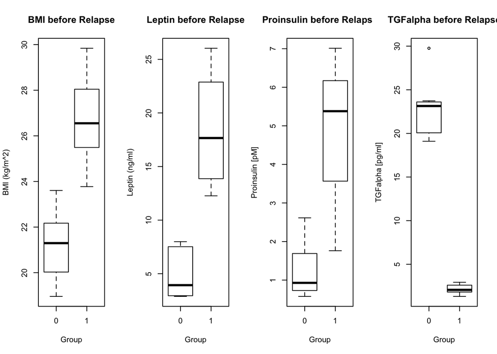

Estimation of BMI and Blood Based Markers in short (0) and long(1) term relapse groups from Boxplots in [Figure 3](http://www.nature.com/tp/journal/v2/n2/fig_tab/tp20123f3.html#figure-title) using Runuran.

```r
# Replicate Figure 3 and Figure 4 diagrams from paper
# http://www.statmethods.net/graphs/boxplot.html
par(mfrow=c(1,4))
boxplot(BMI_TR~Group, data = boxplot.final, main="BMI before Relapse", xlab="Group", ylab="BMI (kg/m^2)" )
boxplot(Leptin_TR~Group, data = boxplot.final, main="Leptin before Relapse", xlab="Group", ylab="Leptin (ng/ml)" )
boxplot(Proinsulin_TR~Group, data = boxplot.final, main="Proinsulin before Relapse", xlab="Group", ylab="Proinsulin [pM]" )
boxplot(TGFalpha_TR~Group, data = boxplot.final, main="TGFalpha before Relapse", xlab="Group", ylab="TGFalpha [pg/ml]" )
```

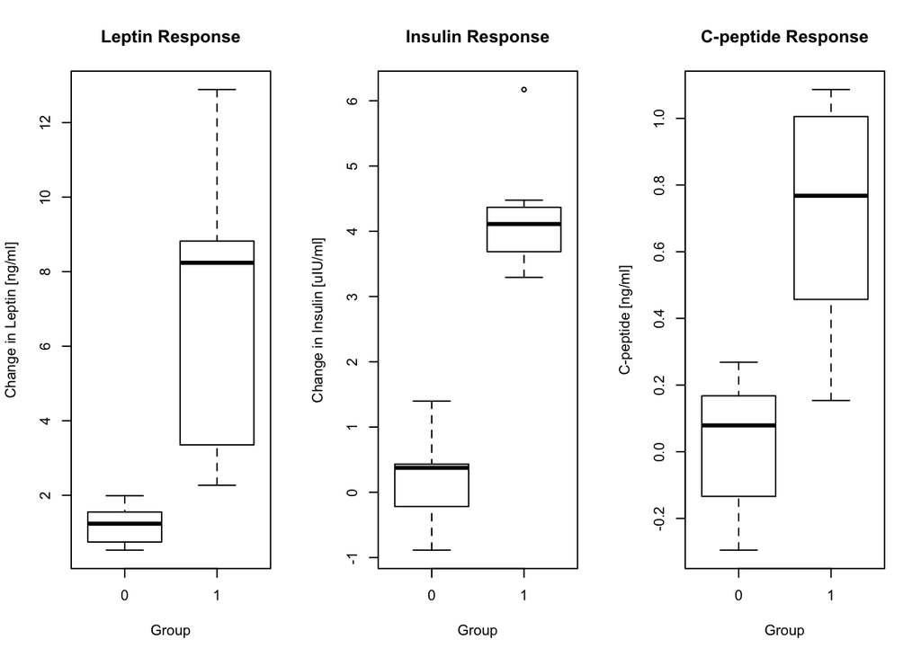

Estimation of the Change in Blood Based Markers after Six Weeks Treatment of Blood Based Markers from Boxplots in [Figure 4](http://www.nature.com/tp/journal/v2/n2/fig_tab/tp20123f4.html#figure-title) using Runuran.

```r
par(mfrow=c(1,3))
boxplot(Leptin_T6T0~Group, data = boxplot.final, main="Leptin Response", xlab="Group", ylab="Change in Leptin [ng/ml]" )
boxplot(Insulin_T6T0~Group, data = boxplot.final, main="Insulin Response", xlab="Group", ylab="Change in Insulin [uIU/ml]" )
boxplot(CPeptide_T6T0~Group, data = boxplot.final, main="C-peptide Response", xlab="Group", ylab="C-peptide [ng/ml]")
```

After shuffling the rows in the table, I then added several clinical or demographic variables that were found not to be significantly correlated to response derived from probability or normal distributions.

```r
# ********** Add Clinical Variables to Blood Marker Variables ************ #

# Add *mainly* independent variables to data frame, use N=15 but probabilities for N=18
# http://www.cookbook-r.com/Manipulating_data/Randomizing_order/
# data <- data[sample(1:nrow(data)), ]
boxplot.mix <- boxplot.final[sample(1:nrow(boxplot.final)), ]
boxplot.mix$Age_TR <- rnorm(15, mean = Age_TR_mean, sd = Age_TR_stddev)
boxplot.mix$Smoke_TR <- rnorm(15, mean = Smoke_TR_mean, sd = Smoke_TR_stddev)
boxplot.mix$Sex_TR <- sample(c(0,1), 15, replace = T, prob = c(12, 6))
boxplot.mix$Cannabis_TR <- sample(c(0,1), 15, replace = T, prob = c(5,13))
boxplot.mix$Treatment_T0 <- sample(c(0,1), 15, replace = T, prob = c(6, 13))
```

As in the paper, I did non-parametric Wilcoxon tests to assess the difference in means between the short term and long term relapse groups for blood marker levels and response as well as for demographic variables.

```r
# http://stackoverflow.com/questions/15639855/how-to-get-a-list-of-pvalues
W_BMI_TR <- wilcox.test(filter(boxplot.mix, Group == 0)$BMI_TR, filter(boxplot.mix, Group == 1)$BMI_TR)$p.value
W_Leptin_TR <- wilcox.test(filter(boxplot.mix, Group == 0)$Leptin_TR, filter(boxplot.mix, Group == 1)$Leptin_TR)$p.value
W_Proinsulin_TR <- wilcox.test(filter(boxplot.mix, Group == 0)$Proinsulin_TR, filter(boxplot.mix, Group == 1)$Proinsulin_TR)$p.value
W_TGFalpha_TR <- wilcox.test(filter(boxplot.mix, Group == 0)$TGFalpha_TR, filter(boxplot.mix, Group == 1)$TGFalpha_TR)$p.value
W_Leptin_T6T0 <- wilcox.test(filter(boxplot.mix, Group == 0)$Leptin_T6T0, filter(boxplot.mix, Group == 1)$Leptin_T6T0)$p.value
W_Insulin_T6T0 <- wilcox.test(filter(boxplot.mix, Group == 0)$Insulin_T6T0, filter(boxplot.mix, Group == 1)$Insulin_T6T0)$p.value
W_CPeptide_T6T0 <- wilcox.test(filter(boxplot.mix, Group == 0)$CPeptide_T6T0, filter(boxplot.mix, Group == 1)$CPeptide_T6T0)$p.value
W_Age_TR <- wilcox.test(filter(boxplot.mix, Group == 0)$Age_TR, filter(boxplot.mix, Group == 1)$Age_TR)$p.value
W_Smoke_TR <- wilcox.test(filter(boxplot.mix, Group == 0)$Smoke_TR, filter(boxplot.mix, Group == 1)$Smoke_TR)$p.value
```

I stored the p values as a vector.

```r
# http://stackoverflow.com/questions/21840021/grabbing-certain-results-out-of-multiple-t-test-outputs-to-create-a-table
W.v <- list(W_BMI_TR, W_Leptin_TR, W_Proinsulin_TR, W_TGFalpha_TR, W_Leptin_T6T0, W_Insulin_T6T0, W_CPeptide_T6T0, W_Age_TR, W_Smoke_TR)
```

I then calculated the means for the short term and long term response groups to store in vectors.

```r
# Calculate mean for each variable for each group
M_BMI_TR.0 <- mean(filter(boxplot.mix, Group == 0)$BMI_TR)
M_BMI_TR.1 <- mean(filter(boxplot.mix, Group == 1)$BMI_TR)
M_Leptin_TR.0 <- mean(filter(boxplot.mix, Group == 0)$Leptin_TR)
M_Leptin_TR.1 <- mean(filter(boxplot.mix, Group == 1)$Leptin_TR)
M_Proinsulin_TR.0 <- mean(filter(boxplot.mix, Group == 0)$Proinsulin_TR)
M_Proinsulin_TR.1 <- mean(filter(boxplot.mix, Group == 1)$Proinsulin_TR)
M_TGFalpha_TR.0 <- mean(filter(boxplot.mix, Group == 0)$TGFalpha_TR)
M_TGFalpha_TR.1 <- mean(filter(boxplot.mix, Group == 1)$Leptin_T6T0)
M_Leptin_T6T0.0 <- mean(filter(boxplot.mix, Group == 0)$Leptin_T6T0)
M_Leptin_T6T0.1 <- mean(filter(boxplot.mix, Group == 1)$Leptin_T6T0)
M_Insulin_T6T0.0 <- mean(filter(boxplot.mix, Group == 0)$Insulin_T6T0)
M_Insulin_T6T0.1 <- mean(filter(boxplot.mix, Group == 1)$Insulin_T6T0)
M_CPeptide_T6T0.0 <- mean(filter(boxplot.mix, Group == 0)$CPeptide_T6T0)
M_CPeptide_T6T0.1 <- mean(filter(boxplot.mix, Group == 1)$CPeptide_T6T0)
M_Age_TR.0 <- mean(filter(boxplot.mix, Group == 0)$Age_TR)
M_Age_TR.1 <- mean(filter(boxplot.mix, Group == 1)$Age_TR)
M_Smoke_TR.0 <- mean(filter(boxplot.mix, Group == 0)$Smoke_TR)
M_Smoke_TR.1 <- mean(filter(boxplot.mix, Group == 1)$Smoke_TR)
M0.v <- c(M_BMI_TR.0, M_Leptin_TR.0, M_Proinsulin_TR.0, M_TGFalpha_TR.0, M_Leptin_T6T0.0, M_Insulin_T6T0.0, M_CPeptide_T6T0.0, M_Age_TR.0, M_Smoke_TR.0)
M1.v <- c(M_BMI_TR.1, M_Leptin_TR.1, M_Proinsulin_TR.1, M_TGFalpha_TR.1, M_Leptin_T6T0.1, M_Insulin_T6T0.1, M_CPeptide_T6T0.1, M_Age_TR.1, M_Smoke_TR.1)
```

I then combined the means and Wilcoxon derived significance values into one table.

```r
# Make data frame: mean between groups, p-value Wilcox test
name.v <- c("BMI", "Leptin", "Proinsulin", "TGF-alpha", "Change Leptin", "Change Insulin", "Change C-peptide", "Age", "Smoke")
wilcox.df <- data.frame(cbind(name.v, M0.v, M1.v, W.v))
wilcox.df <- plyr::rename(wilcox.df, replace = c("name.v"="Variable", "M0.v"="Mean Short", "M1.v"="Mean Long", "W.v"="P Value"), warn_missing = F, warn_duplicated = F)
# http://rmarkdown.rstudio.com/lesson-7.html
#install.packages("knitr")
library("knitr")
kable(wilcox.df, caption = "Difference in means between short and long term relapes and Significance Assessed by Wilcoxon Sum Test")
```

Difference in means between short and long term relapes and Significance Assessed by Wilcoxon Sum Test

[output not shown]

Analysis of the continuous demographic variables show clearly that there is not a significant difference between those generated randomly while there is a significant difference in the bloodmarkers. However, the sample size is small and further assessment of power with more [replicates](http://r.789695.n4.nabble.com/How-to-compute-the-power-of-a-wilcoxon-test-td3815616.html) or different [sample sizes](https://support.sas.com/documentation/cdl/en/statug/63033/HTML/default/viewer.htm#statug_power_sect025.htm) would be helpful.

I did some preliminary code with producing ANCOVA scores using BMI being a potential confounding factor which is still in progress. My strategy is to assess the change in normality with the original distribution and the log10 transformation of these values with the Shapiro Wilkes and qplots. Random Forest analysis was also used to analyse significance although with the amount of information provided about the blood markers, this would be difficult to incorporate into analysis.